# Localization of AMP in LMB2 cultures

Thoenen et al. BX SynComs

Christine Pestalozzi

2025-07-08

The observation that AMPO is formed in cultures of LMB2 supplemented with MBOA and the predicted activity of BxdA, clearly indicate that AMP is formed as an intermediate. Since in a SynCom HMPAA is formed, AMP must be available to the SynCom strains. Here, we tested whether AMP can be detected in the supernatant of LMB2 cultures grown in 0.5x TSB+MBOA.

Metabolite samples were prepared as described before (Thoenen et al 2024, Nat Commun). Samples are quantified based on area under the growth curve. (No standard curves available by mistake)

# Is AMP present in supernatant of LMB2 cultured in presence of MBOA?

This data corresponds to Experiment “25CMP18”, “Objective1”. LMB2 was cultured in 20 mL 1/2 TSB supplemented with 500 uM MBOA for 5 h at 28°C, 180 rpm. As a control LMB2 cultured with DMSO and was used, as well as cultures inoculated with 1/2 TSB instead of LMB2. Three independent cultures were used for each (separate pre-cultures). Different fractions of samples (i.e. supernatant and pellet) were only collected for LMB2 grown in presence of MBOA. At 5 h, samples for metabolite measurements were taken from LMB2 cultures grown with MBOA. For supernatant fraction, 1 mL of sample was pelleted in a 1.5 mL tube at 3200xg for 10 min. The supernatant was transferred to a fresh eppendorf tube and a metabolite sample taken (SN). The pellet was then washed twice with 1/2 TSB containing neither DMSO nor MBOA and resuspended in 1/2 TSB before a metabolite sample was taken (P). As a control, metabolite samples of the whole culture (C) were taken directly. For the NBC controls, only culture samples were taken. Note: that the DMSO control samples were pooled prior to filtering during dilution of the metabolite samples for MS analysis, resulting in 1 replicate. For the MBOA samples, triplicate samples were further processed.

Read in the metadata

Read in the metabolite data (keep only data for compounds that were detected in at least one sample)

Combine the metadata and metabolite data

Colors for plotting etc

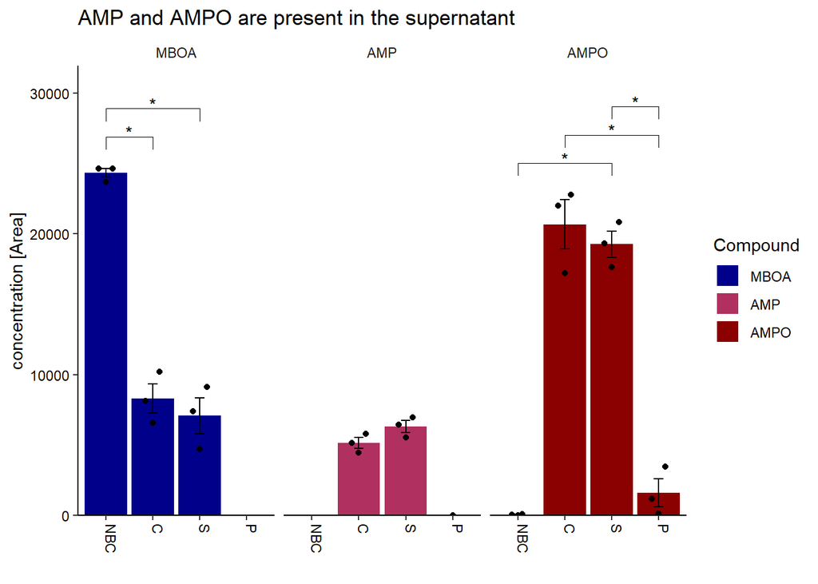